# ML & AI Final

Remahl Aljumaan & Sonia Minocha

2024-04-16

# Data Preprocessing

```r
df <- read.csv("OnlineNewsPopularity.csv", header = TRUE)
df <- df[, !(names(df) == "url")] # removing the URL column
df_factor <- df

# change categorical variables to factor type
cat_cols <- c("weekday_is_monday", "weekday_is_tuesday", "weekday_is_wednesday", "weekday_is_thursday", "weekday_is_friday", "weekday_is_saturday", "weekday_is_sunday", "is_weekend", "data_channel_is_lifestyle", "data_channel_is_entertainment", "data_channel_is_bus", "data_channel_is_socmed", "data_channel_is_tech", "data_channel_is_world")
df_factor[, cat_cols] <- lapply(df_factor[, cat_cols], as.factor)

# turn shares into binary variable w/ threshold 1400 (df_factor only)
df_popular <- df_factor
threshold <- 1400
df_popular$popularity <- ifelse(df_popular$shares >= threshold, 1, 0)
df_popular <- df_popular[, !(names(df_popular) == "shares")] # removing the shares column
```

### Summary Table

```r
# Select continuous features
continuous_cols <- sapply(df_factor, is.numeric)

# Print the summary statistics table
skim_summary <- skim(df_factor[, continuous_cols])
print(skim_summary)
```

```
## ── Data Summary ────────────────────────
##                            Values
## Name                       df_factor[, continuous_co...
## Number of rows             39644
## Number of columns          46
## _______________________
## Column type frequency:
##   numeric                  46
## ________________________
## Group variables            None
##
## ── Variable type: numeric ──────────────────────────────────────────────────────
##    skim_variable                n_missing complete_rate        mean          sd
##  1 timedelta                            0             1    355.        214.
##  2 n_tokens_title                       0             1     10.4         2.11
```

[output cut: 91 more lines]

### Popularity Distribution

```r
popularity_distribution <- table(df_popular$popularity)
print(popularity_distribution)
```

```
##
##     0     1
## 18490 21154
```

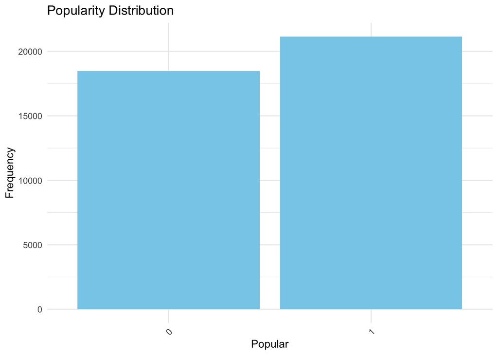

```r
popularity_df <- data.frame(popularity_distribution)

# Create the bar plot using ggplot
ggplot(popularity_df, aes(x = Var1, y = Freq)) +
  geom_bar(stat = "identity", fill = "skyblue") +
  labs(title = "Popularity Distribution", x = "Popular", y = "Frequency") +
  theme_minimal() +
  theme(axis.text.x = element_text(angle = 45, hjust = 1, vjust = 1))  # Rotate x-axis labels if needed
```

### Data Channels Distribution

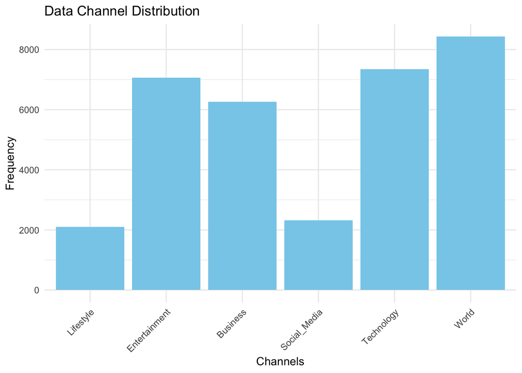

```r
# Create frequency distribution table for all data channels
channel_distribution <- cbind(
  Lifestyle = table(df_factor$data_channel_is_lifestyle),
  Entertainment = table(df_factor$data_channel_is_entertainment),
  Business = table(df_factor$data_channel_is_bus),
  Social_Media = table(df_factor$data_channel_is_socmed),
  Technology = table(df_factor$data_channel_is_tech),
  World = table(df_factor$data_channel_is_world)
)
# Extract the second row values
channel_values <- channel_distribution[2, ]
channel_df <- data.frame(channel = names(channel_values), frequency = channel_values)
channel_order <- names(channel_values)
channel_df$channel <- factor(channel_df$channel, levels = channel_order)

# Create the bar plot using ggplot
ggplot(channel_df, aes(x = channel, y = frequency)) +
  geom_bar(stat = "identity", fill = "skyblue") +
  labs(title = "Data Channel Distribution", x = "Channels", y = "Frequency") +
  theme_minimal() +
  theme(axis.text.x = element_text(angle = 45, hjust = 1, vjust = 1))  # Rotate x-axis labels if needed
```

```r
# Print the combined frequency distribution table
print("Data Channel Distribution:")
```

```
## [1] "Data Channel Distribution:"
```

```r
print(channel_distribution)
```

```
##   Lifestyle Entertainment Business Social_Media Technology World
## 0     37545         32587    33386        37321      32298 31217
## 1      2099          7057     6258         2323       7346  8427
```

### Weekday Distribution

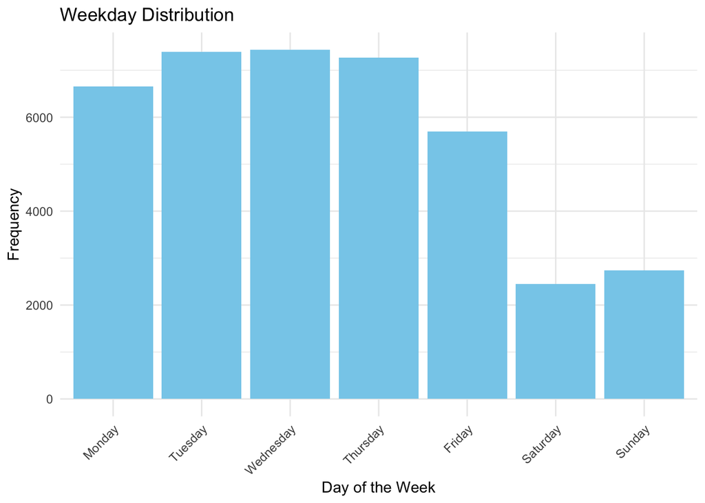

```r
# Create frequency distribution table for all days
weekday_distribution <- cbind(
  Monday = table(df_factor$weekday_is_monday),
  Tuesday = table(df_factor$weekday_is_tuesday),
  Wednesday = table(df_factor$weekday_is_wednesday),
  Thursday = table(df_factor$weekday_is_thursday),
  Friday = table(df_factor$weekday_is_friday),
  Saturday = table(df_factor$weekday_is_saturday),
  Sunday = table(df_factor$weekday_is_sunday)
)
# Extract the second row values
day_values <- weekday_distribution[2, ]
day_df <- data.frame(day = names(day_values), frequency = day_values)
day_order <- names(day_values)
day_df$day <- factor(day_df$day, levels = day_order)

# Create the bar plot using ggplot
ggplot(day_df, aes(x = day, y = frequency)) +
  geom_bar(stat = "identity", fill = "skyblue") +
  labs(title = "Weekday Distribution", x = "Day of the Week", y = "Frequency") +
  theme_minimal() +
  theme(axis.text.x = element_text(angle = 45, hjust = 1, vjust = 1))  # Rotate x-axis labels if needed
```

```r
# Print the combined frequency distribution table
print("Weekday Distribution:")
```

```
## [1] "Weekday Distribution:"
```

```r
print(weekday_distribution)
```

```
##   Monday Tuesday Wednesday Thursday Friday Saturday Sunday
## 0  32983   32254     32209    32377  33943    37191  36907
## 1   6661    7390      7435     7267   5701     2453   2737
```

# Model Development for Regression

### Model Selection

I decided to compare bagging, random forest, and GBM models. I started with a bagging model as it is the simplest to interpret while still being able to handle complex relationships. This model can be computationally expensive, especially given the number of predictors in this data set. Moving to random forests, this model is not as simple to interpret, however can reduce overfitting because of its random feature selection. I thought this would be a good model given the number of features in the article data set, as the data is unlikely to be linear and random forests are robust to noisy data. Finally GBM models can acheive high predictive accuracy and remains robust to nosiy data. It however can be very computationally expensive and requires careful hyperparametric tuning to acheive optimal performance.

### Model Development

```r
B <- 100
n <- nrow(df_factor)
pred <- matrix(NA, nrow = n, ncol = B)

for (i in 1:B) {
    set.seed(i)
    train_idx <- sample(n, n, replace = TRUE)
    oob_idx <- setdiff(1:n, train_idx)

    train_bag <- df_factor[train_idx, ]
    oob <- df_factor[oob_idx, ]

    bag_model <- rpart(shares~., data = train_bag, method = "anova", cp = 0)
    pred[oob_idx, i] <- predict(bag_model, oob)
}

# Calculate OOB mspe
yhat_bag <- rowMeans(pred, na.rm = TRUE, dims = 1)
bag_mspe <- mean((df_factor$shares - yhat_bag)^2)
bag_rmse <- sqrt(bag_mspe)
```

```r
n = nrow(df_factor)
mspe <- rep(NA, 5)

for (i in 1:5) {
    set.seed(i)
    train_idx <- sample(n, n, replace = TRUE)
    test_idx <- setdiff(1:n, train_idx)

    train_rf <- df_factor[train_idx, ]
    test_rf <- df_factor[test_idx, ]

    rf_model <- randomForest(shares ~ ., data = train_rf, ntree = 100)
    yhat_rf <- predict(rf_model, test_rf)

    # Calculate OOB MSPE
    mspe[i] <- mean((test_rf$shares - yhat_rf)^2)
}

rf_rmse <- sqrt(mean(mspe))
```

```r
# create hyperparameter grid
grid <- expand.grid(
  shrinkage = c(0.01, 0.1, 0.3),
  interaction.depth = c(1, 3, 5),
  optimal_trees = 0,               # a place to dump results
  min_RMSE = 0                     # a place to dump results
)

for (i in 1:nrow(grid)) {
  gbm.tune <- gbm(
    formula = shares ~ .,
    distribution = "gaussian",
    data = df,
    n.trees = 1500,
    interaction.depth = grid$interaction.depth[i],
    shrinkage = grid$shrinkage[i],
    cv.folds = 10,
    n.cores = NULL, # will use all cores by default
    verbose = FALSE
  )
  # add min training error and trees to grid
  grid$optimal_trees[i] <- which.min(gbm.tune$cv.error)
  grid$min_RMSE[i] <- sqrt(min(gbm.tune$cv.error))

}
best_params <- grid %>%
  dplyr::arrange(min_RMSE) %>%
  head(1)

# train GBM model
gbm.final <- gbm(
  formula = shares ~ .,
  distribution = "gaussian",
  data = df_factor,
  n.trees = best_params$optimal_trees,
  interaction.depth = best_params$interaction.depth,
  shrinkage = best_params$shrinkage,
  train.fraction = 1,
  cv.folds = 0,
  n.cores = NULL, # will use all cores by default
  verbose = FALSE
  )
```

```r
rmspe <- c()

for (i in 1:100) {
  ind <- unique(sample(1:nrow(df_factor), nrow(df_factor), replace = TRUE))
  train_gbm <- df_factor[ind, ]
  test_gbm <- df_factor[-ind, ]

  gbm.final <- gbm(
    formula = shares ~ .,
    distribution = "gaussian",
    data = train_gbm,
    n.trees = 1000,
    interaction.depth = best_params$interaction.depth,
    shrinkage = best_params$shrinkage,
    train.fraction = 1,
    cv.folds = 0,
    n.cores = NULL, # will use all cores by default
    verbose = FALSE
  )

  yhat_gbm <- predict(gbm.final, test_gbm, n.trees = best_params$optimal_trees)
  rmspe[i] <- sqrt(mean((test_gbm$shares - yhat_gbm)^2))
}

GBM_rmse <- mean(rmspe)
```

### Model Evaluation

```r
# linear regression benchmark
lm_model <- lm(shares ~ ., data = df)
lm_pred <- predict(lm_model, newdata = df)
lm_rmse <- sqrt(mean((df$shares - lm_pred)^2))

# Calculate percentage errors
percentage_errors <- abs((test_rf$shares - yhat_rf) / test_rf$shares) * 100
squared_percentage_errors <- percentage_errors^2
mean_squared_percentage_error <- mean(squared_percentage_errors)
rf_rmspe <- sqrt(mean_squared_percentage_error)
mspe_std <- sd(squared_percentage_errors)

percentage_errors_lm <- abs((df$shares - lm_pred) / df$shares) * 100
squared_percentage_errors_lm <- percentage_errors_lm^2
mean_squared_percentage_error_lm <- mean(squared_percentage_errors_lm)
lm_rmspe <- sqrt(mean_squared_percentage_error_lm)
lm_mspe_std <- sd(squared_percentage_errors_lm)

# Put the values in a data frame
rmse_df <- data.frame(Model = c("Bagging", "Random Forest", "GBM", "Linear Regression"),
                      RMSE = c(bag_rmse, rf_rmse, GBM_rmse, lm_rmse),
                      RMSPE = c(NA, rf_rmspe, NA, lm_rmspe),
                      Uncertainty = c(NA, mspe_std, NA, lm_mspe_std))
rmse_df
```

```
##               Model     RMSE     RMSPE Uncertainty
## 1           Bagging 11652.40        NA          NA
## 2     Random Forest 10655.42  506.5901    12743447
## 3               GBM 11393.49        NA          NA
## 4 Linear Regression 11489.08 4030.4099  3126347479
```

WINNING REGRESSION MODEL: RANDOM FOREST

The best performing model was the random forest with an RMSE of 10655.42, almost 1000 less than the benchmark linear regression model. The random forest model returned a root mean squared percentage error of 506.59 with uncertainty of 12743447 while the benchmark linear regression returned a root mean squared percentage error of 4030.41.

# Regression Model Interpretation

```r
importance(rf_model)
```

```
##                               IncNodePurity
## timedelta                      106113354549
## n_tokens_title                  62746719990
## n_tokens_content               174208338476
## n_unique_tokens                 98238540498
## n_non_stop_words               134958286063
## n_non_stop_unique_tokens       100558029490
## num_hrefs                       97756670433
## num_self_hrefs                  65216317293
## num_imgs                        78161113113
## num_videos                      23142999611
## average_token_length           127400488996
## num_keywords                    21021288629
## data_channel_is_lifestyle        4970585764
## data_channel_is_entertainment    5696184609
## data_channel_is_bus             20625200557
## data_channel_is_socmed           1510084161
## data_channel_is_tech            20563859476
## data_channel_is_world            3673474494
## kw_min_min                      10837154804
## kw_max_min                     107050848451
## kw_avg_min                     102306328654
## kw_min_max                      41134891901
## kw_max_max                      78179460692
## kw_avg_max                     146560559555
## kw_min_avg                      68260299493
## kw_max_avg                     265831570285
## kw_avg_avg                     238621388793
## self_reference_min_shares       87741247007
## self_reference_max_shares      141161036654
## self_reference_avg_sharess     185962857155
## weekday_is_monday               24557434525
## weekday_is_tuesday               6850881005
## weekday_is_wednesday            13818956964
## weekday_is_thursday              8071875774
## weekday_is_friday                5524687527
## weekday_is_saturday              4777989222
## weekday_is_sunday                2573230973
## is_weekend                       3931900676
## LDA_00                         134167204824
## LDA_01                          84734419828
## LDA_02                         104538577531
## LDA_03                          96321828879
## LDA_04                         141199073183
## global_subjectivity             81618502584
## global_sentiment_polarity       75129112139
## global_rate_positive_words      71501965418
## global_rate_negative_words      53965260562
## rate_positive_words             58350507398
## rate_negative_words             39924140786
## avg_positive_polarity           76391324710
## min_positive_polarity           32116381164
## max_positive_polarity           22492483572
## avg_negative_polarity          117635590430
## min_negative_polarity           58276273313
## max_negative_polarity           56906592037
## title_subjectivity              50984743658
## title_sentiment_polarity        91073797031
## abs_title_subjectivity          50122602367
## abs_title_sentiment_polarity    28929581752
```

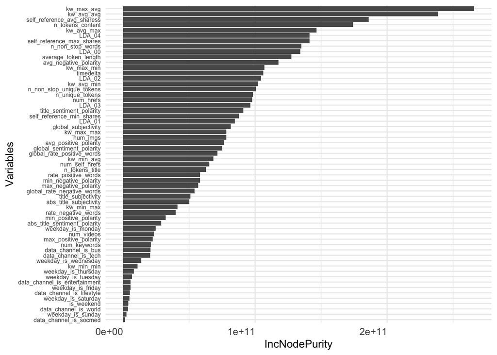

```r
importance_data <- importance(rf_model)
importance_df <- as.data.frame(importance_data)
importance_df$Variable <- rownames(importance_df)

ggplot(importance_df, aes(x = reorder(Variable, IncNodePurity), y = IncNodePurity)) +
  geom_bar(stat = "identity") +
  coord_flip() +  # Flip coordinates for horizontal layout
  theme_minimal() +
  xlab("Variables") +
  ylab("IncNodePurity") +
  theme(axis.text.x = element_text(size = 10, angle = 0, hjust = 1)) +
  theme(axis.text.y = element_text(size = 6, angle = 0, hjust = 1))
```

# Model Development for Classification

BAGGING, RANDOM FOREST & LPM

Bagging can handle multiple factors that may influence popularity by generating multiple bootstrap samples from the original dataset and training a base model on each sample.

Random forest is an extension of bagging that uses decision trees as a base model. Random forest is able to handle high-dimensional feature spaces and nonlinear relationships.

### Model Development

```r
set.seed(1)
AUC_lpm <- c()


for (i in 1:50) {
  ind <- unique(sample(nrow(df_popular), nrow(df_popular), replace = TRUE))
  train <- df_popular[ind, ]
  test <- df_popular[-ind, ]

  # Fit Linear Probability Model (LPM)
 model <- glm(popularity ~ n_tokens_title + n_non_stop_unique_tokens + num_hrefs + num_self_hrefs + average_token_length + num_keywords + data_channel_is_entertainment + data_channel_is_bus + data_channel_is_socmed + data_channel_is_tech + kw_min_min + kw_avg_min + kw_min_max + kw_max_avg + kw_avg_avg + self_reference_min_shares + weekday_is_monday + weekday_is_tuesday + weekday_is_wednesday + weekday_is_thursday + weekday_is_friday + weekday_is_saturday + LDA_00 + LDA_01 + LDA_02 + LDA_03 + global_subjectivity + title_subjectivity + title_sentiment_polarity + abs_title_subjectivity, family = binomial, data = train)


  phat_lpm <- predict(model, test, type = "response")

  # Exclude NAs in predictions
  phat_lpm <- pmin(pmax(phat_lpm, 0), 1, na.rm = TRUE)

  # Calculate LPM AUC
  pred_rocr <- prediction(phat_lpm, test$popularity)
  auc_ROCR <- performance(pred_rocr, measure = "auc")
  AUC_lpm[i] <- auc_ROCR@y.values[[1]]
}
mean_AUC_lpm <- mean(AUC_lpm)
cat("Mean AUC for LPM:", mean_AUC_lpm, "\n")
```

```
## Mean AUC for LPM: 0.704401
```

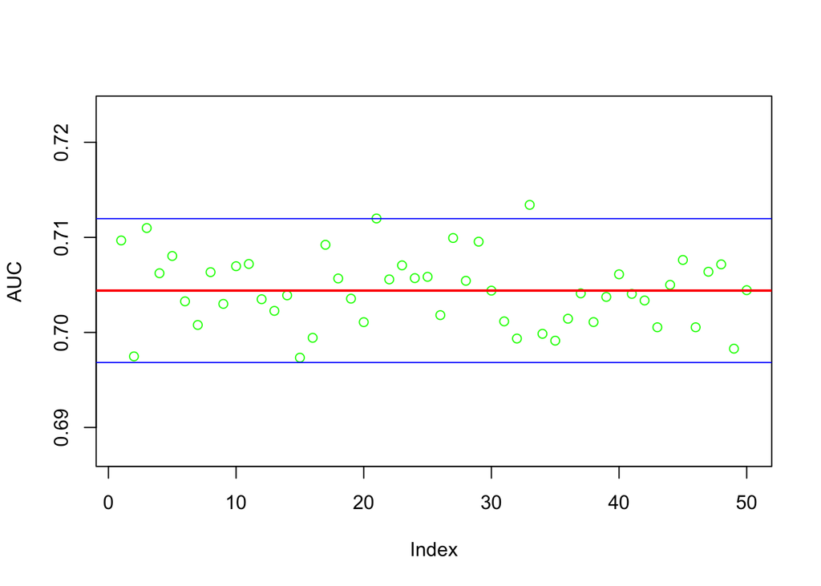

```r
# Plot AUC for LPM with confidence intervals
plot(AUC_lpm, ylab = "AUC", col = "green", ylim = c(min(AUC_lpm) - 0.01, max(AUC_lpm) + 0.01))
abline(h = mean(AUC_lpm), col = "red", lwd = 2)
abline(h = mean(AUC_lpm) + 2 * sd(AUC_lpm), col = "blue")
abline(h = mean(AUC_lpm) - 2 * sd(AUC_lpm), col = "blue")
```

```r
predictions <- ifelse(phat_lpm > 0.5, 1, 0)

# Create confusion matrix
lpm_conf_matrix <- table(predictions, test$popularity)

# Calculate accuracy
lpm_accuracy <- sum(diag(lpm_conf_matrix)) / sum(lpm_conf_matrix)

# Calculate precision
lpm_precision <- lpm_conf_matrix[2, 2] / sum(lpm_conf_matrix[, 2])

# Calculate recall
lpm_recall <- lpm_conf_matrix[2, 2] / sum(lpm_conf_matrix[2, ])

# Calculate F1 score
lpm_f1_score <- 2 * (lpm_precision * lpm_recall) / (lpm_precision + lpm_recall)
```

```r
B <- 100
set.seed(1)
ind <- sample(nrow(df_popular), nrow(df_popular) * 0.8)
train_bag_class <- df_popular[ind, ]
test_bag_class <- df_popular[-ind, ]

#Initialize matrices
phat3 <- matrix(0, B, nrow(test_bag_class))
bagging_AUC <- c()
OOB_errors <- numeric(B)

for (i in 1:B) {
   set.seed(i)


   idx <- sample(nrow(train_bag_class), nrow(train_bag_class), replace = TRUE)
   dt <- train_bag_class[idx, ]


   fit <- rpart(
     popularity ~ n_tokens_title + n_non_stop_unique_tokens + num_hrefs + num_self_hrefs + average_token_length + num_keywords + data_channel_is_entertainment + data_channel_is_bus + data_channel_is_socmed + data_channel_is_tech + kw_min_min + kw_avg_min + kw_min_max + kw_max_avg + kw_avg_avg + self_reference_min_shares + weekday_is_monday + weekday_is_tuesday + weekday_is_wednesday + weekday_is_thursday + weekday_is_friday + weekday_is_saturday + LDA_00 + LDA_01 + LDA_02 + LDA_03 + global_subjectivity + title_subjectivity + title_sentiment_polarity + abs_title_subjectivity,
     cp = 0,
     data = dt,
     method = "class"
   )

   #Predict OOB
   phat3[i, ] <- predict(fit, test_bag_class, type = "prob")[, 2]

   #Calculate OOB error
   OOB_errors[i] <- mean(ifelse(phat3[i, ] > 0.5, 1, 0) != test_bag_class$popularity)


   phat_f <- colMeans(phat3[1:i, , drop = FALSE])


   #AUC
   pred_rocr <- prediction(phat_f, test_bag_class$popularity)
   auc_ROCR <- performance(pred_rocr, measure = "auc")
   bagging_AUC[i] <- auc_ROCR@y.values[[1]]
}

#Calculate the mean AUC over all iterations
bagging_mean_AUC <- mean(bagging_AUC)

#Overall OOB confusion matrix
oob_pred <- as.factor(ifelse(colMeans(phat3) > 0.5, "1", "0"))
oob_actual <- as.factor(test_bag_class$popularity)
overall_OOB_conf_matrix <- confusionMatrix(oob_pred, oob_actual)

#Print the overall OOB confusion matrix
print(overall_OOB_conf_matrix)
```

```
## Confusion Matrix and Statistics
##
##           Reference
## Prediction    0    1
##          0 2147 1186
##          1 1569 3027
##
##                Accuracy : 0.6525
##                  95% CI : (0.6419, 0.663)
##     No Information Rate : 0.5313
##     P-Value [Acc > NIR] : < 2.2e-16
##
##                   Kappa : 0.2981
##
##  Mcnemar's Test P-Value : 3.392e-13
##
##             Sensitivity : 0.5778
##             Specificity : 0.7185
##          Pos Pred Value : 0.6442
##          Neg Pred Value : 0.6586
##              Prevalence : 0.4687
##          Detection Rate : 0.2708
##    Detection Prevalence : 0.4204
##       Balanced Accuracy : 0.6481
##
##        'Positive' Class : 0
##
```

```r
#Calculate the mean OOB error rate over all iterations
mean_OOB_error <- mean(OOB_errors[1:B])

#Print the mean AUC and mean OOB error rate
cat("Bagging Mean AUC:", bagging_mean_AUC, "\n")
```

```
## Bagging Mean AUC: 0.7024493
```

```r
cat("Mean OOB Error Rate:", mean_OOB_error, "\n")
```

```
## Mean OOB Error Rate: 0.4208299
```

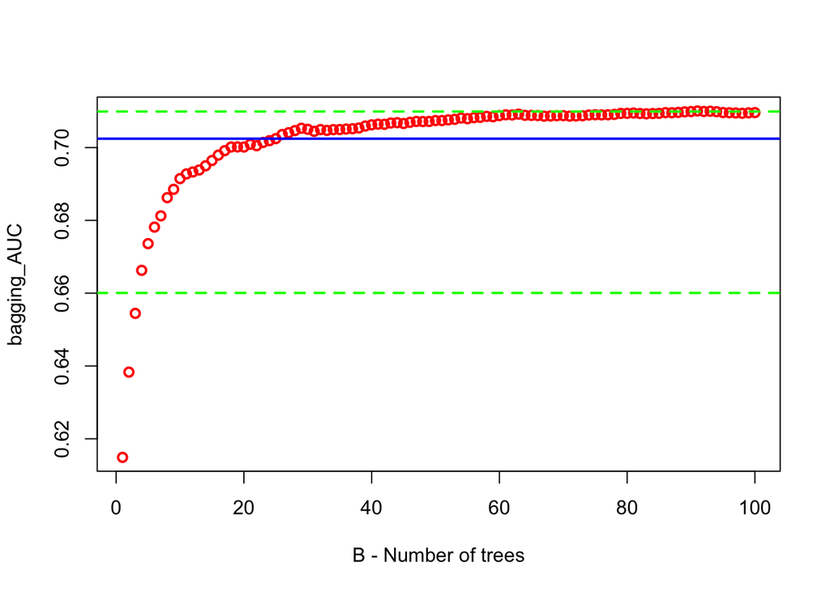

```r
plot(bagging_AUC, col = "red",
     xlab = "B - Number of trees",
     lwd = 2)
abline(h = mean(bagging_AUC), col = "blue", lwd = 2)
abline(h = quantile(bagging_AUC, 0.025), col = "green", lwd = 2, lty = 2)
abline(h = quantile(bagging_AUC, 0.975), col = "green", lwd = 2, lty = 2)
```

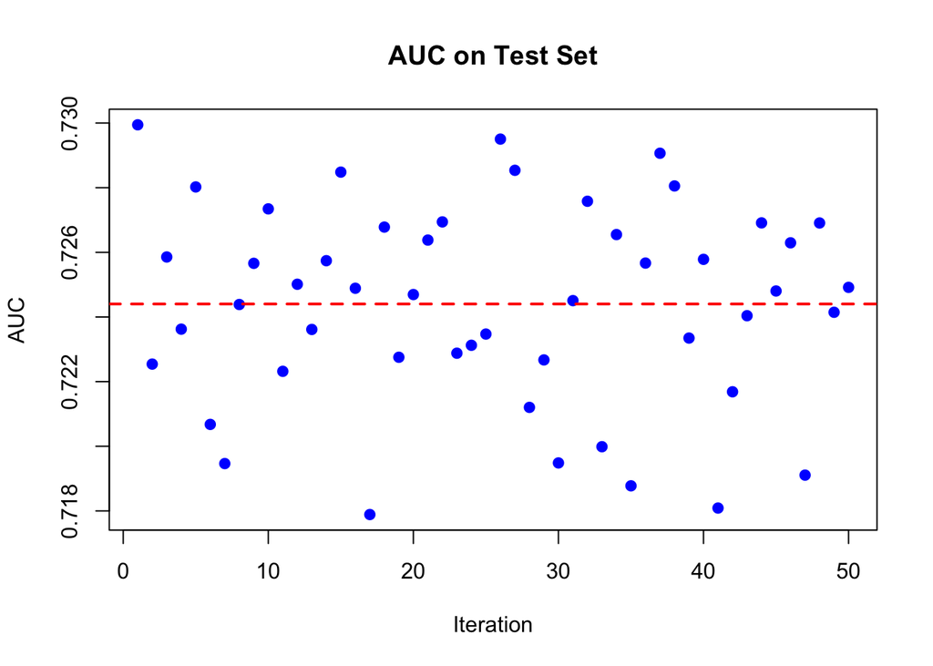

```r
df_popular$popularity <- factor(df_popular$popularity, levels = c(0, 1))

library(pROC)


n = nrow(df_popular)
AUC_rf <- rep(NA, 50)

for (i in 1:50) {
    set.seed(i)
    train_idx <- sample(n, n, replace = TRUE)
    test_idx <- setdiff(1:n, train_idx)

    train_rf_class <- df_popular[train_idx, ]
    test_rf_class <- df_popular[test_idx, ]

    rf_model_class <- randomForest(popularity ~ ., data = train_rf_class, ntree = 100)
    phat <- predict(rf_model_class, test_rf_class, type = "prob")[, 2]

    roc_curve <- roc(test_rf_class$popularity, phat)
    AUC_rf[i] <- auc(roc_curve)
}
mean_AUC_rf <- mean(AUC_rf)
plot(AUC_rf, pch = 19, col = "blue", xlab = "Iteration", ylab = "AUC", main = "AUC on Test Set")
abline(h = mean(AUC_rf), lwd = 2, lty = 2, col = "red")
```

```r
print(rf_model_class)
```

```
##
## Call:
##  randomForest(formula = popularity ~ ., data = train_rf_class,      ntree = 100)
##                Type of random forest: classification
##                      Number of trees: 100
## No. of variables tried at each split: 7
##
##         OOB estimate of  error rate: 12.58%
## Confusion matrix:
##       0     1 class.error
## 0 15462  2827   0.1545738
## 1  2161 19194   0.1011941
```

```r
cat("RF Mean AUC:", mean_AUC_rf, "\n")
```

```
## RF Mean AUC: 0.7244022
```

### Model Evaluation

WINNING CLASSIFICATION MODEL: RANDOM FOREST

With a mean AUC of 0.72, the random forest algorithm outperforms the LPM and bagging models. The higher AUC indicates a stronger performance in ranking articles by their likelihood of being popular. It also has the lower OOB rate in comparison to bagging, which indicates a better generalization performance and discrimination ability.

The random forest model also outperformed the benchmark LPM model in terms of classification performance metrics (AUC, accuracy, precision, recall, F1 score). The random forest confusion matrix also exhibited lower classification errors and higher true positive and true negative rates compared to LPM, indicating effectiveness in predicting popularity.

```r
# Access the confusion matrix from rf_model
rf_conf_matrix <- rf_model_class$confusion

# Calculate accuracy
rf_accuracy <- sum(diag(rf_conf_matrix)) / sum(rf_conf_matrix)

# Calculate precision
rf_precision <- rf_conf_matrix[2, 2] / sum(rf_conf_matrix[, 2])

# Calculate recall (sensitivity)
rf_recall <- rf_conf_matrix[2, 2] / sum(rf_conf_matrix[2, ])

# Calculate F1 score
rf_F1_score <- 2 * rf_precision * rf_recall / (rf_precision + rf_recall)

# Print the metrics of winning model
cat("RF Mean AUC:", mean_AUC_rf, "\n")
```

```
## RF Mean AUC: 0.7244022
```

```r
cat("RF Accuracy:", rf_accuracy, "\n")
```

```
## RF Accuracy: 0.8741746
```

```r
cat("RF Precision:", rf_precision, "\n")
```

```
## RF Precision: 0.8716225
```

```r
cat("RF Recall:", rf_recall, "\n")
```

```
## RF Recall: 0.8988016
```

```r
cat("RF F1 Score:", rf_F1_score, "\n")
```

```
## RF F1 Score: 0.8850035
```

```r
cat("RF Confusion Matrix:","\n")
```

```
## RF Confusion Matrix:
```

```r
print(rf_conf_matrix)
```

```
##       0     1 class.error
## 0 15462  2827   0.1545738
## 1  2161 19194   0.1011941
```

```r
# Print the metrics of benchmark model
cat("LPM Mean AUC:", mean_AUC_lpm, "\n")
```

```
## LPM Mean AUC: 0.704401
```

```r
cat("LPM Accuracy:", lpm_accuracy, "\n")
```

```
## LPM Accuracy: 0.6529283
```

```r
cat("LPM Precision:", lpm_precision, "\n")
```

```
## LPM Precision: 0.7022045
```

```r
cat("LPM Recall:", lpm_recall, "\n")
```

```
## LPM Recall: 0.6644303
```

```r
cat("LPM F1 Score:", lpm_f1_score, "\n")
```

```
## LPM F1 Score: 0.6827954
```

```r
cat("LPM Confusion Matrix:","\n")
```

```
## LPM Confusion Matrix:
```

```r
print(lpm_conf_matrix)
```

```
##
## predictions    0    1
##           0 4074 2310
##           1 2751 5447
```

# Classification Model Interpretation

```r
#Variable importance for RF Classification
importance(rf_model_class)
```

```
##                               MeanDecreaseGini
## timedelta                            605.07066
## n_tokens_title                       296.24736
## n_tokens_content                     448.72870
## n_unique_tokens                      482.75636
## n_non_stop_words                     449.76490
## n_non_stop_unique_tokens             491.65160
## num_hrefs                            391.48060
## num_self_hrefs                       241.25255
## num_imgs                             264.32082
## num_videos                           149.62043
## average_token_length                 505.50118
## num_keywords                         193.07268
## data_channel_is_lifestyle             28.68239
## data_channel_is_entertainment        178.88752
## data_channel_is_bus                   35.35182
## data_channel_is_socmed                84.44230
## data_channel_is_tech                 116.53706
## data_channel_is_world                 98.94337
## kw_min_min                            85.38858
## kw_max_min                           479.80024
## kw_avg_min                           540.55768
## kw_min_max                           319.26143
## kw_max_max                           112.89648
## kw_avg_max                           537.90924
## kw_min_avg                           405.93198
## kw_max_avg                           810.05001
## kw_avg_avg                           869.99920
## self_reference_min_shares            566.17581
## self_reference_max_shares            431.20265
## self_reference_avg_sharess           552.32562
## weekday_is_monday                     46.90384
## weekday_is_tuesday                    49.51943
## weekday_is_wednesday                  53.60709
## weekday_is_thursday                   47.62075
## weekday_is_friday                     44.07414
## weekday_is_saturday                   70.83606
## weekday_is_sunday                     42.69919
## is_weekend                           185.64900
## LDA_00                               550.35279
## LDA_01                               574.61439
## LDA_02                               624.19914
## LDA_03                               501.80420
## LDA_04                               576.80591
## global_subjectivity                  515.38779
## global_sentiment_polarity            475.68721
## global_rate_positive_words           488.29793
## global_rate_negative_words           429.34930
## rate_positive_words                  379.52421
## rate_negative_words                  389.40779
## avg_positive_polarity                479.55753
## min_positive_polarity                231.73492
## max_positive_polarity                194.54730
## avg_negative_polarity                447.17927
## min_negative_polarity                271.42728
## max_negative_polarity                260.54689
## title_subjectivity                   238.57388
## title_sentiment_polarity             285.86107
## abs_title_subjectivity               230.98800
## abs_title_sentiment_polarity         233.53766
```

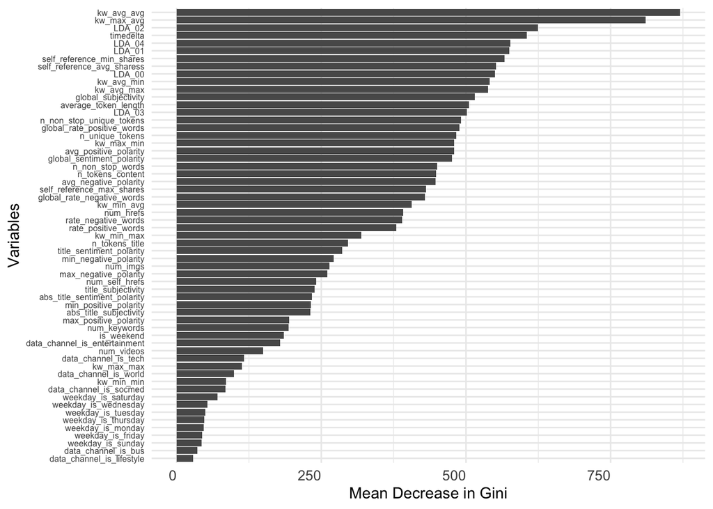

```r
importance_data <- importance(rf_model_class)
importance_df <- as.data.frame(importance_data)
importance_df$Variable <- rownames(importance_df)

ggplot(importance_df, aes(x = reorder(Variable, MeanDecreaseGini), y = MeanDecreaseGini)) +
  geom_bar(stat = "identity") +
  coord_flip() +
  theme_minimal() +
  xlab("Variables") +
  ylab("Mean Decrease in Gini") +
  theme(axis.text.x = element_text(size = 10, angle = 0, hjust = 1)) +
  theme(axis.text.y = element_text(size = 6, angle = 0, hjust = 1))
```

# Conclusion

In analyzing the Online News Popularity dataset, several key findings and insights emerged, providing valuable insights for content creators aiming to enhance article popularity on Mashable.

The analysis underscores the importance of self-referenced articles and the strategic use of average and popular keywords in driving article popularity on Mashable. Content creators should focus on incorporating these elements into their content strategy to maximize engagement and shares. Additionally, leveraging the insights gained from predictive modeling can inform editorial decisions and optimize content creation processes.

Despite the success of the models, challenges such as data quality and the dynamic nature of online content popularity were encountered. Future research could explore more sophisticated modeling techniques and incorporate real-time data streams to enhance predictive accuracy. Additionally, further investigation into user engagement patterns and preferences could provide deeper insights into factors driving article popularity.

In summary, this project utilized regression and classification models to predict article popularity on Mashable, yielding actionable insights for content creators. The Random Forest models emerged as top performers, emphasizing the significance of self-referenced articles and keyword optimization in driving engagement. By leveraging these findings, content creators can tailor their strategies to enhance article popularity and audience engagement, ultimately maximizing the impact of their content on online platforms.